# Bellabeat Case Study

by Sanjay Paul on March 14, 2022

# Case Study: How Can a Wellness Technology Company Play It Smart?

[figure not shown]

#### Introduction

Bellabeat is a small but successful high-tech company & manufacturer of health-focused smart products for women that are designed to analyze fitness data. They have the potential to become a larger player in the global smart device market. Company’s products include a health tracking app, wellness tracking bracelets, watches, and a water bottle that tracks daily water intake.

Urška Sršen and Sando Mur founded Bellabeat, Since it was founded in 2013, Bellabeat has grown rapidly and quickly positioned itself as a tech-driven wellness company for women. By 2016, Bellabeat had opened offices around the world and launched multiple products. Bellabeat has become a widely successful company, and they are looking to grow the company. Sršen knows that an analysis of Bellabeat’s available consumer data would reveal more opportunities for growth.

Some of company’s products are:

- **Bellabeat app:** The Bellabeat app provides users with health data related to their activity, sleep, stress, menstrual cycle, and mindfulness habits. This data can help users better understand their current habits and make healthy decisions. The Bellabeat app connects to their line of smart wellness products.
- **Leaf:** Bellabeat’s classic wellness tracker can be worn as a bracelet, necklace, or clip. The Leaf tracker connects to the Bellabeat app to track activity, sleep, and stress.
- **Time:** This wellness watch combines the timeless look of a classic timepiece with smart technology to track user activity, sleep, and stress. The Time watch connects to the Bellabeat app to provide you with insights into your daily wellness.
- **Spring:** This is a water bottle that tracks daily water intake using smart technology to ensure that you are appropriately hydrated throughout the day. The Spring bottle connects to the Bellabeat app to track your hydration levels.
- **Bellabeat membership:** Bellabeat also offers a subscription-based membership program for users. Membership gives users 24/7 access to fully personalized guidance on nutrition, activity, sleep, health and beauty, and mindfulness based on their lifestyle and goals.

[figure not shown]

# Ask / Task

**Stakeholders:**

- Urška Sršen: Bellabeat’s cofounder and Chief Creative Officer
- Sando Mur: Mathematician and Bellabeat’s cofounder; key member of the Bellabeat executive team
- Bellabeat marketing analytics team

**Goal of Analysis:**

Analyze smart device usage data in order to gain insight into existing competitor or how consumers use non-Bellabeat smart devices. and apply these insights to in your presentation for answers to below questions.

**Key Questions:**

1. Explore data to find out what are some trends in smart device usage?

2. Out line the trend & How could these trends apply to Bellabeat customers?

3. How could these trends help influence Bellabeat marketing strategy & share analysis and recommendations?

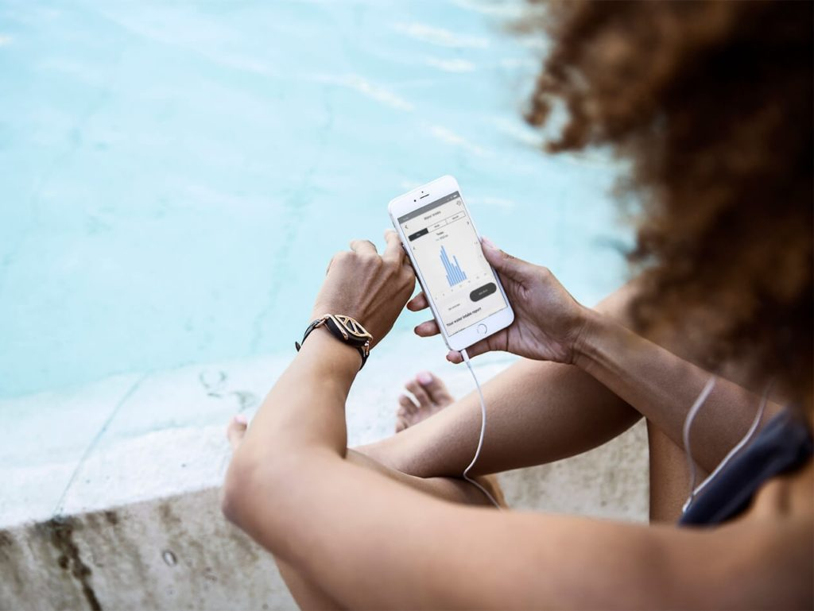

# Prepare

Thirty eligible Fitbit users consented to the submission of personal tracker data, including minute-level output for physical activity, heart rate, and sleep monitoring. Individual reports can be parsed by export session ID (column A) or timestamp (column B). Variation between output represents use of different types of Fitbit trackers and individual tracking behaviors / preferences.

[Download](https://www.kaggle.com/arashnic/fitbit) and unzip the 18 CSV documents and began exploration

This data has limited insight due to only being thirty people used for the survey. Also the demographics of this group is anonymous. and participant’s age, gender, and lifestyle are unknown. Bellabeats is a health tracking company targeted for women so data given specifically by women with more sample size would have been ideal for this analysis. Initially we can check the data in spreadsheets and then upload them to suitable program. Here R Studio will be used to complete this analysis.

Dataset contains categories of data tables such as :

- Daily records(Activity, calories, Intensities, steps)
- Hourly Records ( Calories, Intensities, steps)
- By minutes records( Calories, Intensities, METs, steps and sleep)
- Sleep record
- Heart rate record
- Weight log

Some of the data in tables isn’t in consistent or correct format, so process the data & checking for errors, cleaning, merging and formatting data before start analysis. also need to convert “Date” in the format which shows “Day of the week”. As well as the “ActivityHour” had date comined. Formatting this data to separate “Date and time”. This allowed me to get “Day of the week” as well as “time”.

# Process

Install and load the below mentioned packages and libraries as needed

tidyverse, skimr, dplyr, janitor, ggplot2, and sqldf

```r
#loading packages
#install.packages("tidyverse")
library("tidyverse")
#install.packages("skimr")
library("skimr")
#install.packages("dplyr")
library("dplyr")
#install.packages("janitor")
library("janitor")
```

```r
#install.packages("ggplot2")
library("ggplot2")
#install.packages("sqldf")
library("sqldf")
library("readr")
```

Loading 14 files out of 18 csv files by eliminating the redudant files(choosing narrow datasets) .

```r
daily_activity <- read.csv("Fitabase Data 4.12.16-5.12.16/dailyActivity_merged.csv")
daily_calories <- read.csv("Fitabase Data 4.12.16-5.12.16/dailyCalories_merged.csv")
daily_intensities <- read.csv("Fitabase Data 4.12.16-5.12.16/dailyIntensities_merged.csv")
daily_steps <- read.csv("Fitabase Data 4.12.16-5.12.16/dailySteps_merged.csv")
hourly_calories <- read.csv("Fitabase Data 4.12.16-5.12.16/hourlyCalories_merged.csv")
hourly_intensities <- read.csv("Fitabase Data 4.12.16-5.12.16/hourlyIntensities_merged.csv")
hourly_steps <- read.csv("Fitabase Data 4.12.16-5.12.16/hourlySteps_merged.csv")
minute_calories <- read.csv("Fitabase Data 4.12.16-5.12.16/minuteCaloriesNarrow_merged.csv")
minute_intensities <-read.csv("Fitabase Data 4.12.16-5.12.16/minuteIntensitiesNarrow_merged.csv")
minute_steps <- read.csv("Fitabase Data 4.12.16-5.12.16/minuteStepsNarrow_merged.csv")
minute_sleep <- read.csv("Fitabase Data 4.12.16-5.12.16/minuteSleep_merged.csv")
sleep_day <- read.csv("Fitabase Data 4.12.16-5.12.16/sleepDay_merged.csv")
weight_log <- read.csv("Fitabase Data 4.12.16-5.12.16/weightLogInfo_merged.csv")
heartrate_seconds <- read.csv("Fitabase Data 4.12.16-5.12.16/heartrate_seconds_merged.csv")
```

**Viewing the files**

Viewing the datasets by using str function and head function. str function returns the structure of the datasets and head fuunction returns the first 6 rows of the corresponding datsets.

```r
str(daily_activity)
```

```
## 'data.frame':    940 obs. of  15 variables:
##  $ Id                      : num  1.5e+09 1.5e+09 1.5e+09 1.5e+09 1.5e+09 ...
##  $ ActivityDate            : chr  "4/12/2016" "4/13/2016" "4/14/2016" "4/15/2016" ...
##  $ TotalSteps              : int  13162 10735 10460 9762 12669 9705 13019 15506 10544 9819 ...
##  $ TotalDistance           : num  8.5 6.97 6.74 6.28 8.16 ...
##  $ TrackerDistance         : num  8.5 6.97 6.74 6.28 8.16 ...
##  $ LoggedActivitiesDistance: num  0 0 0 0 0 0 0 0 0 0 ...
##  $ VeryActiveDistance      : num  1.88 1.57 2.44 2.14 2.71 ...
##  $ ModeratelyActiveDistance: num  0.55 0.69 0.4 1.26 0.41 ...
##  $ LightActiveDistance     : num  6.06 4.71 3.91 2.83 5.04 ...
##  $ SedentaryActiveDistance : num  0 0 0 0 0 0 0 0 0 0 ...
##  $ VeryActiveMinutes       : int  25 21 30 29 36 38 42 50 28 19 ...
##  $ FairlyActiveMinutes     : int  13 19 11 34 10 20 16 31 12 8 ...
##  $ LightlyActiveMinutes    : int  328 217 181 209 221 164 233 264 205 211 ...
##  $ SedentaryMinutes        : int  728 776 1218 726 773 539 1149 775 818 838 ...
##  $ Calories                : int  1985 1797 1776 1745 1863 1728 1921 2035 1786 1775 ...
```

```r
head(daily_activity)
```

```
##           Id ActivityDate TotalSteps TotalDistance TrackerDistance
## 1 1503960366    4/12/2016      13162          8.50            8.50
## 2 1503960366    4/13/2016      10735          6.97            6.97
## 3 1503960366    4/14/2016      10460          6.74            6.74
## 4 1503960366    4/15/2016       9762          6.28            6.28
## 5 1503960366    4/16/2016      12669          8.16            8.16
## 6 1503960366    4/17/2016       9705          6.48            6.48
##   LoggedActivitiesDistance VeryActiveDistance ModeratelyActiveDistance
## 1                        0               1.88                     0.55
## 2                        0               1.57                     0.69
## 3                        0               2.44                     0.40
## 4                        0               2.14                     1.26
## 5                        0               2.71                     0.41
## 6                        0               3.19                     0.78
##   LightActiveDistance SedentaryActiveDistance VeryActiveMinutes
## 1                6.06                       0                25
## 2                4.71                       0                21
## 3                3.91                       0                30
## 4                2.83                       0                29
## 5                5.04                       0                36
## 6                2.51                       0                38
##   FairlyActiveMinutes LightlyActiveMinutes SedentaryMinutes Calories
## 1                  13                  328              728     1985
## 2                  19                  217              776     1797
## 3                  11                  181             1218     1776
## 4                  34                  209              726     1745
## 5                  10                  221              773     1863
## 6                  20                  164              539     1728
```

```r
str(daily_calories)
```

```
## 'data.frame':    940 obs. of  3 variables:
##  $ Id         : num  1.5e+09 1.5e+09 1.5e+09 1.5e+09 1.5e+09 ...
##  $ ActivityDay: chr  "4/12/2016" "4/13/2016" "4/14/2016" "4/15/2016" ...
##  $ Calories   : int  1985 1797 1776 1745 1863 1728 1921 2035 1786 1775 ...
```

```r
head(daily_calories)
```

```
##           Id ActivityDay Calories
## 1 1503960366   4/12/2016     1985
## 2 1503960366   4/13/2016     1797
## 3 1503960366   4/14/2016     1776
## 4 1503960366   4/15/2016     1745
## 5 1503960366   4/16/2016     1863
## 6 1503960366   4/17/2016     1728
```

```r
str(daily_intensities)
```

```
## 'data.frame':    940 obs. of  10 variables:
##  $ Id                      : num  1.5e+09 1.5e+09 1.5e+09 1.5e+09 1.5e+09 ...
##  $ ActivityDay             : chr  "4/12/2016" "4/13/2016" "4/14/2016" "4/15/2016" ...
##  $ SedentaryMinutes        : int  728 776 1218 726 773 539 1149 775 818 838 ...
##  $ LightlyActiveMinutes    : int  328 217 181 209 221 164 233 264 205 211 ...
##  $ FairlyActiveMinutes     : int  13 19 11 34 10 20 16 31 12 8 ...
##  $ VeryActiveMinutes       : int  25 21 30 29 36 38 42 50 28 19 ...
##  $ SedentaryActiveDistance : num  0 0 0 0 0 0 0 0 0 0 ...
##  $ LightActiveDistance     : num  6.06 4.71 3.91 2.83 5.04 ...
##  $ ModeratelyActiveDistance: num  0.55 0.69 0.4 1.26 0.41 ...
##  $ VeryActiveDistance      : num  1.88 1.57 2.44 2.14 2.71 ...
```

```r
head(daily_intensities)
```

```
##           Id ActivityDay SedentaryMinutes LightlyActiveMinutes
## 1 1503960366   4/12/2016              728                  328
## 2 1503960366   4/13/2016              776                  217
## 3 1503960366   4/14/2016             1218                  181
## 4 1503960366   4/15/2016              726                  209
## 5 1503960366   4/16/2016              773                  221
## 6 1503960366   4/17/2016              539                  164
##   FairlyActiveMinutes VeryActiveMinutes SedentaryActiveDistance
## 1                  13                25                       0
## 2                  19                21                       0
## 3                  11                30                       0
## 4                  34                29                       0
## 5                  10                36                       0
## 6                  20                38                       0
##   LightActiveDistance ModeratelyActiveDistance VeryActiveDistance
## 1                6.06                     0.55               1.88
## 2                4.71                     0.69               1.57
## 3                3.91                     0.40               2.44
## 4                2.83                     1.26               2.14
## 5                5.04                     0.41               2.71
## 6                2.51                     0.78               3.19
```

```r
str(daily_steps)
```

```
## 'data.frame':    940 obs. of  3 variables:
##  $ Id         : num  1.5e+09 1.5e+09 1.5e+09 1.5e+09 1.5e+09 ...
##  $ ActivityDay: chr  "4/12/2016" "4/13/2016" "4/14/2016" "4/15/2016" ...
##  $ StepTotal  : int  13162 10735 10460 9762 12669 9705 13019 15506 10544 9819 ...
```

```r
head(daily_steps)
```

```
##           Id ActivityDay StepTotal
## 1 1503960366   4/12/2016     13162
## 2 1503960366   4/13/2016     10735
## 3 1503960366   4/14/2016     10460
## 4 1503960366   4/15/2016      9762
## 5 1503960366   4/16/2016     12669
## 6 1503960366   4/17/2016      9705
```

```r
str(hourly_calories)
```

```
## 'data.frame':    22099 obs. of  3 variables:
##  $ Id          : num  1.5e+09 1.5e+09 1.5e+09 1.5e+09 1.5e+09 ...
##  $ ActivityHour: chr  "4/12/2016 12:00:00 AM" "4/12/2016 1:00:00 AM" "4/12/2016 2:00:00 AM" "4/12/2016 3:00:00 AM" ...
##  $ Calories    : int  81 61 59 47 48 48 48 47 68 141 ...
```

```r
head(hourly_calories)
```

```
##           Id          ActivityHour Calories
## 1 1503960366 4/12/2016 12:00:00 AM       81
## 2 1503960366  4/12/2016 1:00:00 AM       61
## 3 1503960366  4/12/2016 2:00:00 AM       59
## 4 1503960366  4/12/2016 3:00:00 AM       47
## 5 1503960366  4/12/2016 4:00:00 AM       48
## 6 1503960366  4/12/2016 5:00:00 AM       48
```

```r
str(hourly_intensities)
```

```
## 'data.frame':    22099 obs. of  4 variables:
##  $ Id              : num  1.5e+09 1.5e+09 1.5e+09 1.5e+09 1.5e+09 ...
##  $ ActivityHour    : chr  "4/12/2016 12:00:00 AM" "4/12/2016 1:00:00 AM" "4/12/2016 2:00:00 AM" "4/12/2016 3:00:00 AM" ...
##  $ TotalIntensity  : int  20 8 7 0 0 0 0 0 13 30 ...
##  $ AverageIntensity: num  0.333 0.133 0.117 0 0 ...
```

```r
head(hourly_intensities)
```

```
##           Id          ActivityHour TotalIntensity AverageIntensity
## 1 1503960366 4/12/2016 12:00:00 AM             20         0.333333
## 2 1503960366  4/12/2016 1:00:00 AM              8         0.133333
## 3 1503960366  4/12/2016 2:00:00 AM              7         0.116667
## 4 1503960366  4/12/2016 3:00:00 AM              0         0.000000
## 5 1503960366  4/12/2016 4:00:00 AM              0         0.000000
## 6 1503960366  4/12/2016 5:00:00 AM              0         0.000000
```

```r
str(hourly_steps)
```

```
## 'data.frame':    22099 obs. of  3 variables:
##  $ Id          : num  1.5e+09 1.5e+09 1.5e+09 1.5e+09 1.5e+09 ...
##  $ ActivityHour: chr  "4/12/2016 12:00:00 AM" "4/12/2016 1:00:00 AM" "4/12/2016 2:00:00 AM" "4/12/2016 3:00:00 AM" ...
##  $ StepTotal   : int  373 160 151 0 0 0 0 0 250 1864 ...
```

```r
head(hourly_steps)
```

```
##           Id          ActivityHour StepTotal
## 1 1503960366 4/12/2016 12:00:00 AM       373
## 2 1503960366  4/12/2016 1:00:00 AM       160
## 3 1503960366  4/12/2016 2:00:00 AM       151
## 4 1503960366  4/12/2016 3:00:00 AM         0
## 5 1503960366  4/12/2016 4:00:00 AM         0
## 6 1503960366  4/12/2016 5:00:00 AM         0
```

```r
str(minute_calories)
```

```
## 'data.frame':    1325580 obs. of  3 variables:
##  $ Id            : num  1.5e+09 1.5e+09 1.5e+09 1.5e+09 1.5e+09 ...
##  $ ActivityMinute: chr  "4/12/2016 12:00:00 AM" "4/12/2016 12:01:00 AM" "4/12/2016 12:02:00 AM" "4/12/2016 12:03:00 AM" ...
##  $ Calories      : num  0.786 0.786 0.786 0.786 0.786 ...
```

```r
head(minute_calories)
```

```
##           Id        ActivityMinute Calories
## 1 1503960366 4/12/2016 12:00:00 AM   0.7865
## 2 1503960366 4/12/2016 12:01:00 AM   0.7865
## 3 1503960366 4/12/2016 12:02:00 AM   0.7865
## 4 1503960366 4/12/2016 12:03:00 AM   0.7865
## 5 1503960366 4/12/2016 12:04:00 AM   0.7865
## 6 1503960366 4/12/2016 12:05:00 AM   0.9438
```

```r
str(minute_intensities)
```

```
## 'data.frame':    1325580 obs. of  3 variables:
##  $ Id            : num  1.5e+09 1.5e+09 1.5e+09 1.5e+09 1.5e+09 ...
##  $ ActivityMinute: chr  "4/12/2016 12:00:00 AM" "4/12/2016 12:01:00 AM" "4/12/2016 12:02:00 AM" "4/12/2016 12:03:00 AM" ...
##  $ Intensity     : int  0 0 0 0 0 0 0 0 0 0 ...
```

```r
head(minute_intensities)
```

```
##           Id        ActivityMinute Intensity
## 1 1503960366 4/12/2016 12:00:00 AM         0
## 2 1503960366 4/12/2016 12:01:00 AM         0
## 3 1503960366 4/12/2016 12:02:00 AM         0
## 4 1503960366 4/12/2016 12:03:00 AM         0
## 5 1503960366 4/12/2016 12:04:00 AM         0
## 6 1503960366 4/12/2016 12:05:00 AM         0
```

```r
str(minute_sleep)
```

```
## 'data.frame':    188521 obs. of  4 variables:
##  $ Id   : num  1.5e+09 1.5e+09 1.5e+09 1.5e+09 1.5e+09 ...
##  $ date : chr  "4/12/2016 2:47:30 AM" "4/12/2016 2:48:30 AM" "4/12/2016 2:49:30 AM" "4/12/2016 2:50:30 AM" ...
##  $ value: int  3 2 1 1 1 1 1 2 2 2 ...
##  $ logId: num  1.14e+10 1.14e+10 1.14e+10 1.14e+10 1.14e+10 ...
```

```r
head(minute_sleep)
```

```
##           Id                 date value       logId
## 1 1503960366 4/12/2016 2:47:30 AM     3 11380564589
## 2 1503960366 4/12/2016 2:48:30 AM     2 11380564589
## 3 1503960366 4/12/2016 2:49:30 AM     1 11380564589
## 4 1503960366 4/12/2016 2:50:30 AM     1 11380564589
## 5 1503960366 4/12/2016 2:51:30 AM     1 11380564589
## 6 1503960366 4/12/2016 2:52:30 AM     1 11380564589
```

```r
str(sleep_day)
```

```
## 'data.frame':    413 obs. of  5 variables:
##  $ Id                : num  1.5e+09 1.5e+09 1.5e+09 1.5e+09 1.5e+09 ...
##  $ SleepDay          : chr  "4/12/2016 12:00:00 AM" "4/13/2016 12:00:00 AM" "4/15/2016 12:00:00 AM" "4/16/2016 12:00:00 AM" ...
##  $ TotalSleepRecords : int  1 2 1 2 1 1 1 1 1 1 ...
##  $ TotalMinutesAsleep: int  327 384 412 340 700 304 360 325 361 430 ...
##  $ TotalTimeInBed    : int  346 407 442 367 712 320 377 364 384 449 ...
```

```r
head(sleep_day)
```

```
##           Id              SleepDay TotalSleepRecords TotalMinutesAsleep
## 1 1503960366 4/12/2016 12:00:00 AM                 1                327
## 2 1503960366 4/13/2016 12:00:00 AM                 2                384
## 3 1503960366 4/15/2016 12:00:00 AM                 1                412
## 4 1503960366 4/16/2016 12:00:00 AM                 2                340
## 5 1503960366 4/17/2016 12:00:00 AM                 1                700
## 6 1503960366 4/19/2016 12:00:00 AM                 1                304
##   TotalTimeInBed
## 1            346
## 2            407
## 3            442
## 4            367
## 5            712
## 6            320
```

```r
str(weight_log)
```

```
## 'data.frame':    67 obs. of  8 variables:
##  $ Id            : num  1.50e+09 1.50e+09 1.93e+09 2.87e+09 2.87e+09 ...
##  $ Date          : chr  "5/2/2016 11:59:59 PM" "5/3/2016 11:59:59 PM" "4/13/2016 1:08:52 AM" "4/21/2016 11:59:59 PM" ...
##  $ WeightKg      : num  52.6 52.6 133.5 56.7 57.3 ...
##  $ WeightPounds  : num  116 116 294 125 126 ...
##  $ Fat           : int  22 NA NA NA NA 25 NA NA NA NA ...
##  $ BMI           : num  22.6 22.6 47.5 21.5 21.7 ...
##  $ IsManualReport: chr  "True" "True" "False" "True" ...
##  $ LogId         : num  1.46e+12 1.46e+12 1.46e+12 1.46e+12 1.46e+12 ...
```

```r
head(weight_log)
```

```
##           Id                  Date WeightKg WeightPounds Fat   BMI
## 1 1503960366  5/2/2016 11:59:59 PM     52.6     115.9631  22 22.65
## 2 1503960366  5/3/2016 11:59:59 PM     52.6     115.9631  NA 22.65
## 3 1927972279  4/13/2016 1:08:52 AM    133.5     294.3171  NA 47.54
## 4 2873212765 4/21/2016 11:59:59 PM     56.7     125.0021  NA 21.45
## 5 2873212765 5/12/2016 11:59:59 PM     57.3     126.3249  NA 21.69
## 6 4319703577 4/17/2016 11:59:59 PM     72.4     159.6147  25 27.45
##   IsManualReport        LogId
## 1           True 1.462234e+12
## 2           True 1.462320e+12
## 3          False 1.460510e+12
## 4           True 1.461283e+12
## 5           True 1.463098e+12
## 6           True 1.460938e+12
```

```r
str(heartrate_seconds)
```

```
## 'data.frame':    2483658 obs. of  3 variables:
##  $ Id   : num  2.02e+09 2.02e+09 2.02e+09 2.02e+09 2.02e+09 ...
##  $ Time : chr  "4/12/2016 7:21:00 AM" "4/12/2016 7:21:05 AM" "4/12/2016 7:21:10 AM" "4/12/2016 7:21:20 AM" ...
##  $ Value: int  97 102 105 103 101 95 91 93 94 93 ...
```

```r
head(heartrate_seconds)
```

```
##           Id                 Time Value
## 1 2022484408 4/12/2016 7:21:00 AM    97
## 2 2022484408 4/12/2016 7:21:05 AM   102
## 3 2022484408 4/12/2016 7:21:10 AM   105
## 4 2022484408 4/12/2016 7:21:20 AM   103
## 5 2022484408 4/12/2016 7:21:25 AM   101
## 6 2022484408 4/12/2016 7:22:05 AM    95
```

Some of the atrributes are redudant in datasets so we are going to take few datasets and merging few datasets to reduce the redundancy attributes.

**Merging datasets**

- hourly_calories
- hourly_intensities
- hourly_steps
- minute_calories
- minute_intensities
- minute_steps

```r
hourly_activity0 <-merge(x = hourly_calories, y = hourly_intensities , by = c("Id", "ActivityHour"), all = TRUE)
hourly_activity <-merge(x = hourly_activity0, y = hourly_steps, by = c("Id", "ActivityHour"), all = TRUE)
```

```r
minute_activity0 <-merge(x = minute_calories, y = minute_intensities, by =c("Id", "ActivityMinute"), All = TRUE)
minute_activity <- merge(x = minute_activity0, y = minute_steps, by = c("Id", "ActivityMinute"), All = TRUE)
```

Now we have following datasets : daily_activity, hourly_activity, minute_activity, sleep_day, weight_log

Lets check the data integrity Since 30 fitbit users provided their data there should be 30 unique Ids.Checking the datasets using n_distinct function which count the number of unique values.

```r
n_distinct(daily_activity$Id)
```

```
## [1] 33
```

```r
n_distinct(hourly_activity$Id)
```

```
## [1] 33
```

```r
n_distinct(minute_activity$Id)
```

```
## [1] 33
```

```r
n_distinct(sleep_day$Id)
```

```
## [1] 24
```

```r
n_distinct(weight_log$Id)
```

```
## [1] 8
```

After checking above values, its clear that:

- (daily_activity,hourly_activity and minute_activity) has 33 unique Ids which is more 30 users.
- sleep_day dataset has 24 unique Ids which is less than 30 users.
- weight_log has only 8 unique Ids which is way less than 30 users, so if we use this dataset it will be difficult to make conclusions. but we will try to look into the BMI with data.

**Checking duplicates and NA values**

Duplicated function returns the duplicated values and is.na function returns the NA values. Here we are using sum function to count the duplicated and NA values in the datasets.

```r
sum(duplicated(daily_activity))
```

```
## [1] 0
```

```r
sum(duplicated(hourly_activity))
```

```
## [1] 0
```

```r
sum(duplicated(minute_activity))
```

```
## [1] 0
```

```r
sum(duplicated(sleep_day))
```

```
## [1] 3
```

```r
sum(duplicated(weight_log))
```

```
## [1] 0
```

```r
sum(is.na(daily_activity))
```

```
## [1] 0
```

```r
sum(is.na(hourly_activity))
```

```
## [1] 0
```

```r
sum(is.na(minute_activity))
```

```
## [1] 0
```

```r
sum(is.na(sleep_day))
```

```
## [1] 0
```

```r
sum(is.na(weight_log))
```

```
## [1] 65
```

There are 03 duplicate values in sleep_day dataset hence duplicate values will be removed using distinct function and reassuring the dataset doesn’t contain the duplicates by using the sum function. and there are 65 null values in weight_log dataset which is huge in comparison to sample of its dataset but most of the null values are in column name “Fat” hence this dataset wont be much useful but we can analyse BMI with it later on.

**Removing duplicates**

```r
sleep_day <-sleep_day %>% distinct()
sum(duplicated(sleep_day))
```

```
## [1] 0
```

**Renaming column names**

All the datasets daily_activity, hourly_activity, minute_activity and sleep_day has date and are in different column names and in character datatype. So we are going to format the column names.

```r
daily_activity <- daily_activity %>% rename(Date = ActivityDate)
hourly_activity <- hourly_activity %>% rename(Date = ActivityHour)
minute_activity <- minute_activity %>% rename(Date = ActivityMinute)
sleep_day <- sleep_day %>% rename(Date = SleepDay)
```

**Formatting datatype**

All the datasets has date column and it is a charater datatype. Changing them to date and time format.

```r
daily_activity <- daily_activity %>% mutate(Date = as.POSIXct(Date, format = "%m/%d/%Y"))
hourly_activity <- hourly_activity %>% mutate(Date = as.POSIXct(Date, format = "%m/%d/%Y %I:%M:%S %p", tz=Sys.timezone()))
minute_activity <- minute_activity %>% mutate(Date = as.POSIXct(Date, format = "%m/%d/%Y %I:%M:%S %p", tz=Sys.timezone()))
sleep_day <- sleep_day %>% mutate(Date = as.POSIXct(Date, format = "%m/%d/%Y %I:%M:%S %p", tz=Sys.timezone()))
```

**Seperating column**

Seperating the date column in hourly_activity & minute_activity dataset as date and time column for further analysis. Analysing activity and changes in them on hourly basis might be very useful insights.

```r
hourly_activity <- hourly_activity %>% separate(Date, c("Date", "Time"), sep = " ")
minute_activity <- minute_activity %>% separate(Date, c("Date", "Time"), sep = " ")
```

**Add column**

Now we will add a column (days of week) in daily_activity and sleep_day dataset for analysing how the steps, sleep and other activities changes on the days basis.

```r
daily_activity <- daily_activity %>% mutate(ActivityDay = weekdays(as.Date(Date)))
sleep_day <- sleep_day %>%  mutate(ActivityDay = weekdays(as.Date(Date)))
head(daily_activity)
```

```
##           Id       Date TotalSteps TotalDistance TrackerDistance
## 1 1503960366 2016-04-12      13162          8.50            8.50
## 2 1503960366 2016-04-13      10735          6.97            6.97
## 3 1503960366 2016-04-14      10460          6.74            6.74
## 4 1503960366 2016-04-15       9762          6.28            6.28
## 5 1503960366 2016-04-16      12669          8.16            8.16
## 6 1503960366 2016-04-17       9705          6.48            6.48
##   LoggedActivitiesDistance VeryActiveDistance ModeratelyActiveDistance
## 1                        0               1.88                     0.55
## 2                        0               1.57                     0.69
## 3                        0               2.44                     0.40
## 4                        0               2.14                     1.26
## 5                        0               2.71                     0.41
## 6                        0               3.19                     0.78
##   LightActiveDistance SedentaryActiveDistance VeryActiveMinutes
```

[output cut: 20 more lines]

```r
head(sleep_day)
```

```
##           Id       Date TotalSleepRecords TotalMinutesAsleep TotalTimeInBed
## 1 1503960366 2016-04-12                 1                327            346
## 2 1503960366 2016-04-13                 2                384            407
## 3 1503960366 2016-04-15                 1                412            442
## 4 1503960366 2016-04-16                 2                340            367
## 5 1503960366 2016-04-17                 1                700            712
## 6 1503960366 2016-04-19                 1                304            320
##   ActivityDay
## 1      Monday
## 2     Tuesday
## 3    Thursday
## 4      Friday
## 5    Saturday
## 6      Monday
```

After getting above dataset both the datasets (daily_activity & Sleep_day) will be merge & name it as sleep_activity dataset for better analysis.

```r
sleep_activity <- merge(daily_activity, sleep_day, by =c("Id", "Date", "ActivityDay"))
head(sleep_activity)
```

```
##           Id       Date ActivityDay TotalSteps TotalDistance TrackerDistance
## 1 1503960366 2016-04-12      Monday      13162          8.50            8.50
## 2 1503960366 2016-04-13     Tuesday      10735          6.97            6.97
## 3 1503960366 2016-04-15    Thursday       9762          6.28            6.28
## 4 1503960366 2016-04-16      Friday      12669          8.16            8.16
## 5 1503960366 2016-04-17    Saturday       9705          6.48            6.48
## 6 1503960366 2016-04-19      Monday      15506          9.88            9.88
##   LoggedActivitiesDistance VeryActiveDistance ModeratelyActiveDistance
## 1                        0               1.88                     0.55
## 2                        0               1.57                     0.69
## 3                        0               2.14                     1.26
## 4                        0               2.71                     0.41
## 5                        0               3.19                     0.78
## 6                        0               3.53                     1.32
##   LightActiveDistance SedentaryActiveDistance VeryActiveMinutes
```

[output cut: 20 more lines]

# Analyze

We have now reached to the analyze and share part for this case study. so far we have explored, cleaned, formatted, merged the datasets. now its time to analyse and share the insights from it. our analysis mainly will be base on 06 datasets like: daily_activity, hourly_activity, minute_activity, sleep_day, weight_log, sleep_activity

Using summary() function to get the statistic summary of the datasets.

```r
daily_activity %>%
  select(TotalSteps,
         TotalDistance,
         Calories,
         SedentaryMinutes,
         VeryActiveMinutes,
         FairlyActiveMinutes,
         LightlyActiveMinutes) %>%
  summary()
```

```
##    TotalSteps    TotalDistance       Calories    SedentaryMinutes
##  Min.   :    0   Min.   : 0.000   Min.   :   0   Min.   :   0.0
##  1st Qu.: 3790   1st Qu.: 2.620   1st Qu.:1828   1st Qu.: 729.8
##  Median : 7406   Median : 5.245   Median :2134   Median :1057.5
##  Mean   : 7638   Mean   : 5.490   Mean   :2304   Mean   : 991.2
##  3rd Qu.:10727   3rd Qu.: 7.713   3rd Qu.:2793   3rd Qu.:1229.5
##  Max.   :36019   Max.   :28.030   Max.   :4900   Max.   :1440.0
##  VeryActiveMinutes FairlyActiveMinutes LightlyActiveMinutes
##  Min.   :  0.00    Min.   :  0.00      Min.   :  0.0
##  1st Qu.:  0.00    1st Qu.:  0.00      1st Qu.:127.0
##  Median :  4.00    Median :  6.00      Median :199.0
##  Mean   : 21.16    Mean   : 13.56      Mean   :192.8
##  3rd Qu.: 32.00    3rd Qu.: 19.00      3rd Qu.:264.0
##  Max.   :210.00    Max.   :143.00      Max.   :518.0
```

For general fitness, most adults should aim for 10,000 steps per day. This figure may rise or fall depending on a person’s age, current fitness level, and health goals. This recommendation comes from the Centers for Disease Control and Prevention (CDC). Here we can analyse that average step count it is low. same for other observations too. recommended average distance 8 kilometers or 5 miles. as per google data,By age 75+, people are sedentary for 11 hours per day i.e 660 minutes and here the average counts to even more than this figure.

The CDC also recommends adults getting 150 minutes of physical activity each week, including aerobic activity and muscle-strengthening activity. This can be 30 minutes a day, five days a week. Of the 150 minutes of exercise, 75 minutes needs to be vigorous exercise. In this group, users are getting about 21 minutes of vigorous exercise a day, which equals about 147 minutes of vigorous exercise. Here users are exceeding the recommended amount of vigorous exercise.

```r
sleep_day %>%
  select(TotalMinutesAsleep,
         TotalTimeInBed) %>%
  summary()
```

```
##  TotalMinutesAsleep TotalTimeInBed
##  Min.   : 58.0      Min.   : 61.0
##  1st Qu.:361.0      1st Qu.:403.8
##  Median :432.5      Median :463.0
##  Mean   :419.2      Mean   :458.5
##  3rd Qu.:490.0      3rd Qu.:526.0
##  Max.   :796.0      Max.   :961.0
```

The CDC recommends that a person between 18 and 60 years old should get at least seven hours of sleep per night. Here users spent an average of 419 minutes a night asleep which is close to the 420 minutes/7 Hrs a night recommended by the CDC. Furthermore, the participants only spent about 39 minutes extra as awake in bed which might be because of screen time like use of social media before going for sleep.

Now lets also do small BMI analysis then we will proceed to share and visualize our analysis.

BMI is a measure that compares a person’s weight to their height. The CDC asses BMI range as: BMI < 18.5, = underweight range. 18.5 to 24.9, = normal or Healthy Weight range. 25.0 to 29.9, - overweight range. BMI > 30.0 or higher, = obese range.

```r
weight_log %>%
  select(BMI,
         WeightPounds,
         WeightKg) %>%
  summary()
```

```
##       BMI         WeightPounds      WeightKg
##  Min.   :21.45   Min.   :116.0   Min.   : 52.60
##  1st Qu.:23.96   1st Qu.:135.4   1st Qu.: 61.40
##  Median :24.39   Median :137.8   Median : 62.50
##  Mean   :25.19   Mean   :158.8   Mean   : 72.04
##  3rd Qu.:25.56   3rd Qu.:187.5   3rd Qu.: 85.05
##  Max.   :47.54   Max.   :294.3   Max.   :133.50
```

the average BMI of participants is 25.19, which is slightly in the overweight range. however some BMI charts separates healthy BMI range by gender also and here in the datasets genders are missing which means dataset does not provide clear picture Despite this, of the participants who recorded their BMI, their health habits suggest that if they continue their lifestyle with little improvement. they should start falling into a healthy BMI range soon.

# Share

stakeholders Want an analysis of consumer’s use of an existing competitor/product to identify trends that may lead to potential opportunities for growth. The following charts show the correlation between activity and reaching recommendations.

First we are check the usage of device while in sleep and while being active. for this we will calculate the usage percentage in both the stage.

```r
active_time <- daily_activity %>% select(LightlyActiveMinutes, FairlyActiveMinutes, VeryActiveMinutes, SedentaryMinutes)

Avg_Active_time =  (mean(active_time$VeryActiveMinutes) + mean(active_time$FairlyActiveMinutes) + mean(active_time$LightlyActiveMinutes))

Total_Active_time = sum(mean(active_time$LightlyActiveMinutes), mean(active_time$FairlyActiveMinutes), mean(active_time$VeryActiveMinutes), mean(active_time$SedentaryMinute))

Active_percentile <- (Avg_Active_time / Total_Active_time ) * 100

sleep_Percentile <- (mean(sleep_day$TotalMinutesAsleep) / max(sleep_day$TotalMinutesAsleep) * 100)
```

```r
Usage <- c('Active_Usage', 'Sleep_Usage')
Percentile <- c(Active_percentile, sleep_Percentile)
Device_Usage <- data.frame(Usage, Percentile)
Device_Usage
```

```
##          Usage Percentile
## 1 Active_Usage   18.67011
## 2  Sleep_Usage   52.65995
```

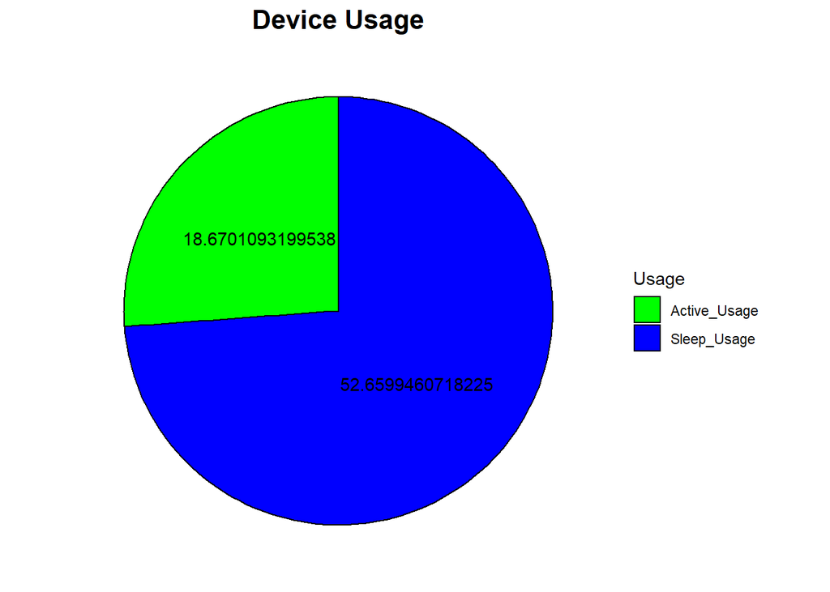

```r
ggplot(Device_Usage, aes(x="", y=Percentile, fill=Usage)) +
  geom_bar(stat = "identity", width = 1, color='black')+
  coord_polar("y", start=0)+
  theme_minimal()+
  theme(axis.title.x= element_blank(),
        axis.title.y = element_blank(),
        panel.border = element_blank(),
        panel.grid = element_blank(),
        axis.ticks = element_blank(),
        axis.text.x = element_blank(),
        plot.title = element_text(hjust = 0.5, size=16, face = "bold")) +
  scale_fill_manual(values = c("green","blue")) +
  geom_text(aes(label = Percentile),
            position = position_stack(vjust = 0.5))+
  labs(title="Device Usage")
```

The pie chart shows that users are using their device more while sleep then while being active.

lets find Relationship between steps taken in a day with calories burnt in a day and with sedentary minutes.

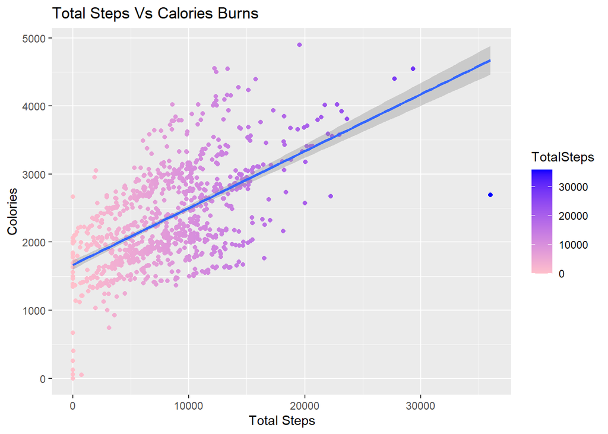

```r
ggplot(data = daily_activity, mapping = aes(x = TotalSteps, y = Calories, color = TotalSteps)) + geom_point() +geom_smooth(method = lm) +
  labs(title = "Total Steps Vs Calories Burns",  x = "Total Steps", y = "Colories") + scale_color_gradient(low = "pink", high = "blue")
```

Output graph shows the positive correlation between Steps and calories burn. the more steps user walk more calories burn.

lets see steps & sedentary correlation

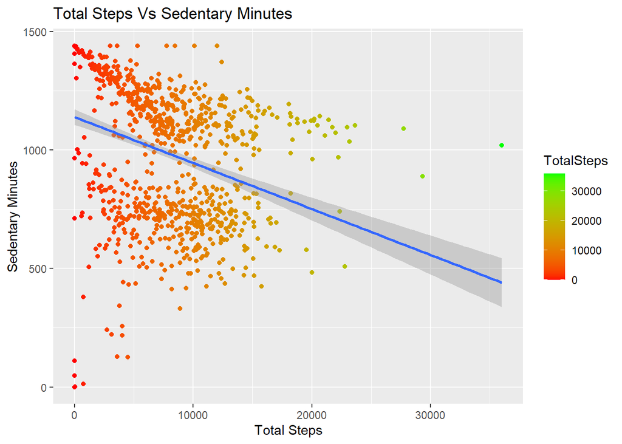

```r
ggplot(data = daily_activity, mapping = aes(x = TotalSteps, y = SedentaryMinutes, color = TotalSteps)) + geom_point() + geom_smooth(method = lm) + labs(title = "Total Steps Vs Sedentary Minutes", x = "Total Steps", y = "Sedentary Minutes") + scale_color_gradient(low = "red", high = "green")
```

output graph shows that if user are more sedentary then they walk less that’s why they take less steps

lets check Total distance cover by walk with calories burnt

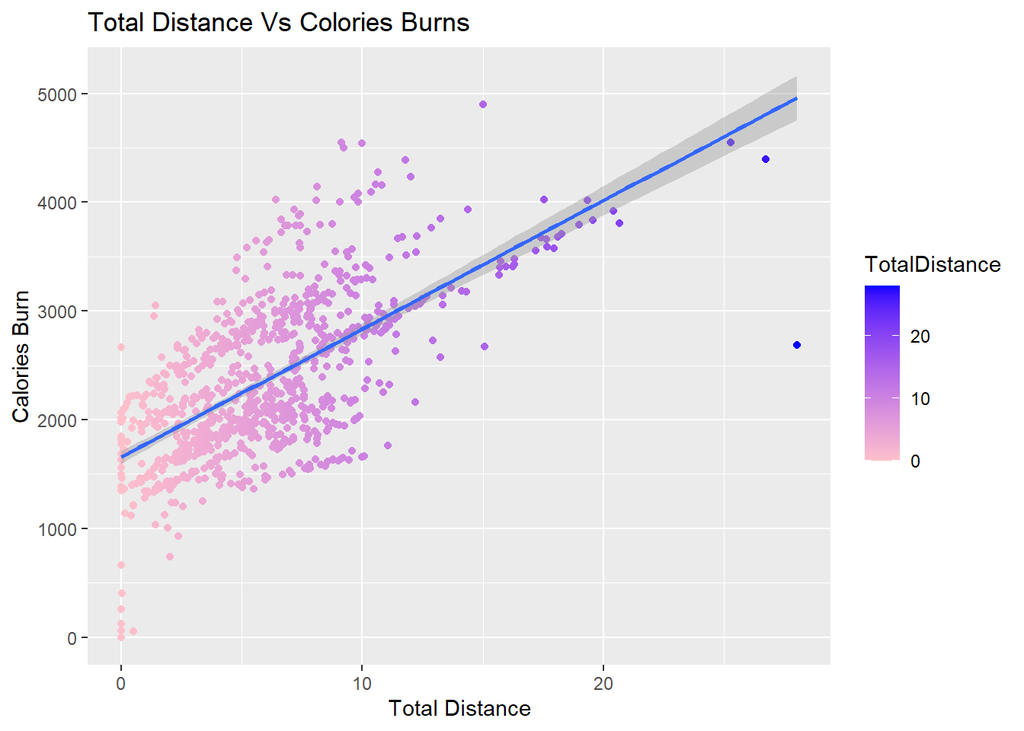

```r
ggplot(data = daily_activity, mapping = aes(x = TotalDistance, y = Calories, color = TotalDistance)) + geom_point() + geom_smooth(method = lm) + labs(title = "Total Distance Vs Colories Burns", x = "Total Distance", y = "Calories Burn") + scale_color_gradient(low = "pink", high = "blue")
```

Output graph shows the positive correlation between Total Distance cover by walk and calories burn. the more distance user walk the more steps they will take and more calories will burn.

now lets see relationship between minutes asleep and time in bed.

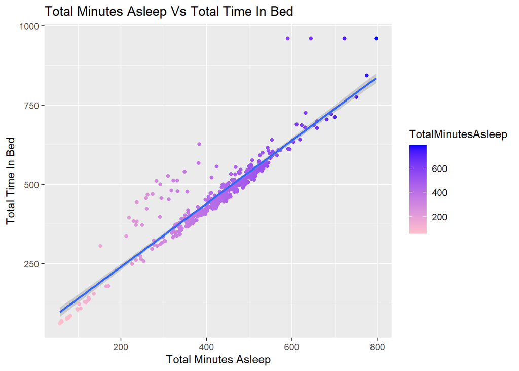

```r
ggplot(data = sleep_day, mapping = aes(x = TotalMinutesAsleep, y = TotalTimeInBed, color = TotalMinutesAsleep)) + geom_point() + geom_smooth(method = lm) + labs(title = "Total Minutes Asleep Vs Total Time In Bed", x = "Total Minutes Asleep", y = "Total Time In Bed") + scale_color_gradient(low = "pink", high = "blue")
```

Output graph shows positive correlation.Which means people spent more time in bed than they fell asleep. this is because of alot of reasons like: using phone or being active on social media before going to sleep which impact our sleep.

Now lets check hourly datasets for more insights

we will try to analysis At what time most steps are taken? At what time most intensity is observed?

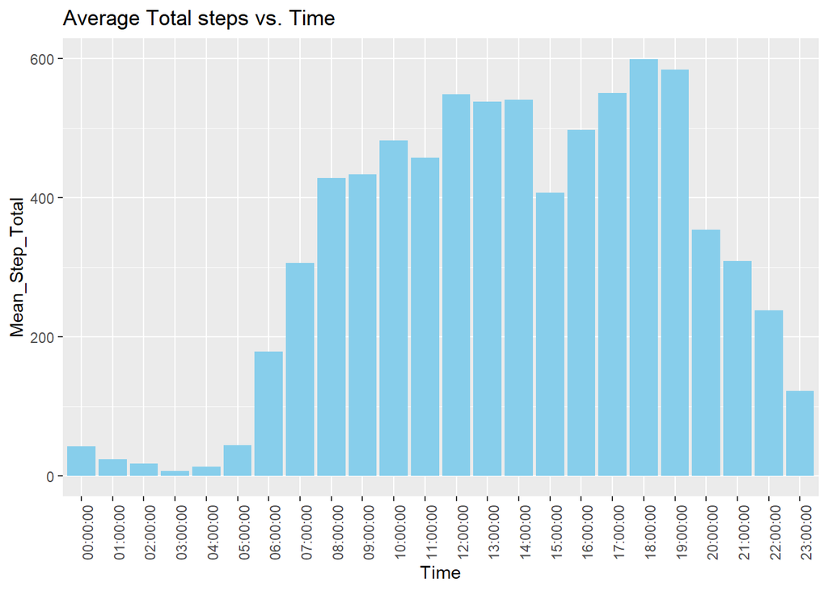

```r
#Checking  at which Hour the most steps are recorded.
hourly_activity_1 = hourly_activity %>%
  group_by(Time) %>%
  summarise(Mean_Step_Total = mean(StepTotal))

ggplot(data=hourly_activity_1, aes(x= Time, y = Mean_Step_Total)) + geom_histogram(stat = "identity", fill='skyblue') +
  theme(axis.text.x = element_text(angle = 90)) +
  labs(title="Average Total steps vs. Time")
```

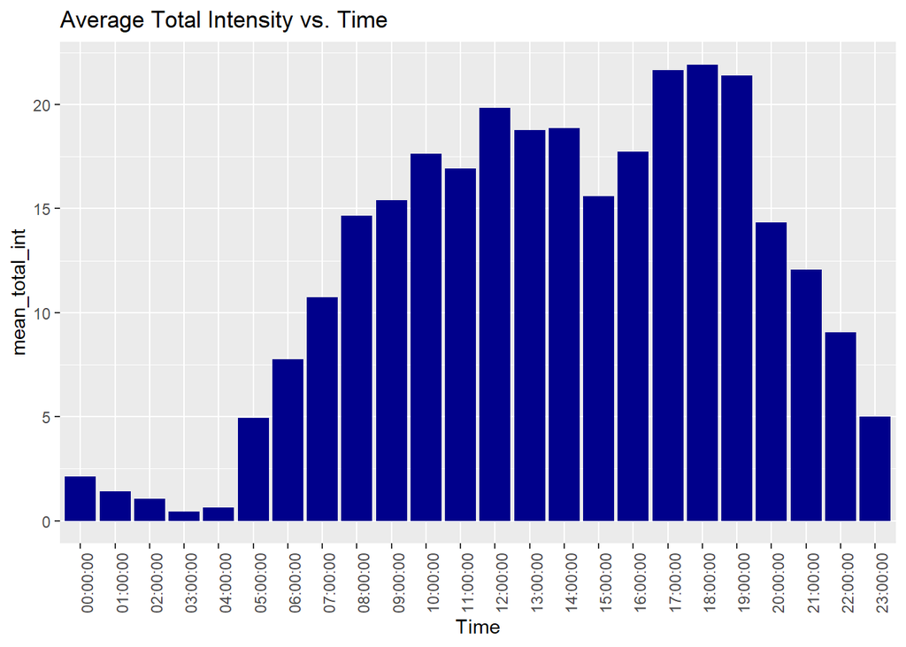

```r
#Checking  at which Hour the most intensity of activity is observed.
new_Hourly_int <- hourly_activity %>%
  group_by(Time) %>%
  drop_na() %>%
  summarise(mean_total_int = mean(TotalIntensity))

ggplot(data=new_Hourly_int, aes(x= Time, y=mean_total_int)) + geom_histogram(stat = "identity", fill='Darkblue') +
  theme(axis.text.x = element_text(angle = 90)) +
  labs(title="Average Total Intensity vs. Time")
```

Both the graphs matches and show the Most steps taken with most intensity in activity is observed during afternoon around 12:00 - 2:00 in the afternoon and around in the evening at 5:00 - 7:00 PM. this data seems to be collected from working professional because peak time of steps or activities are afternoon 12 - 02 & evening 5-7. one is a lunch time in most of the offices and another is the tea time or shift finishes and people go home.

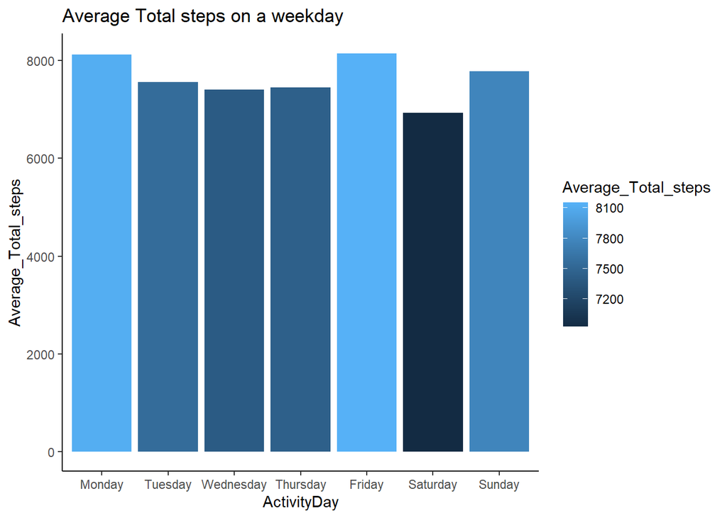

```r
daily_activity$ActivityDay<-factor(daily_activity$ActivityDay,levels=c("Monday","Tuesday","Wednesday","Thursday","Friday","Saturday","Sunday"))

daily_activity%>%
group_by(ActivityDay)%>%
summarise(Average_Total_steps=mean(TotalSteps))%>%
ggplot(aes(x=ActivityDay,y=Average_Total_steps,fill=Average_Total_steps))+geom_bar(stat="identity")+theme_classic()+labs(title="Average Total steps on a weekday")
```

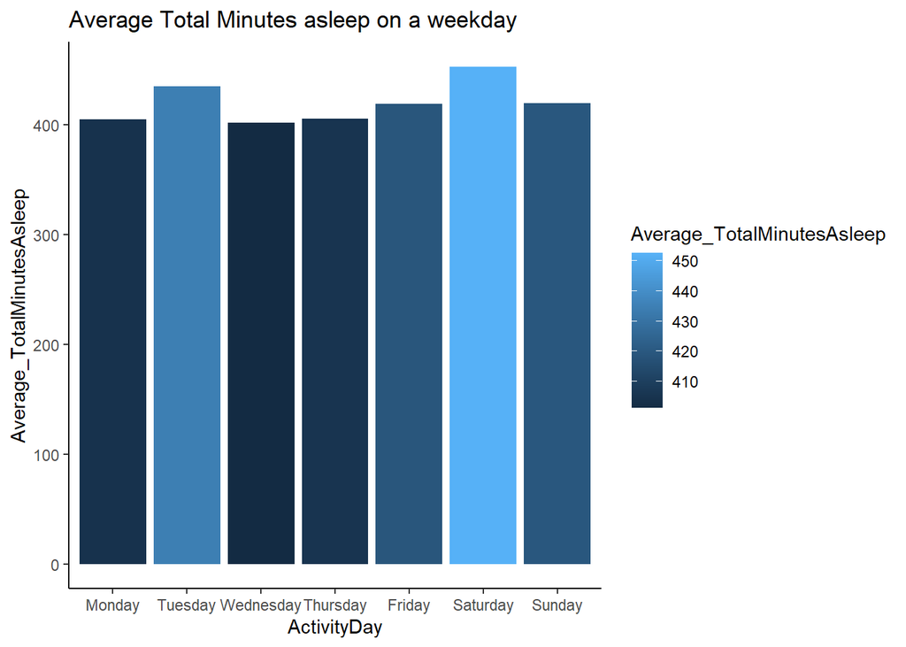

```r
sleep_activity$ActivityDay<-factor(sleep_activity$ActivityDay,levels=c("Monday","Tuesday","Wednesday","Thursday","Friday","Saturday","Sunday"))

sleep_activity%>%
group_by(ActivityDay)%>%
summarise(Average_TotalMinutesAsleep=mean(TotalMinutesAsleep))%>%
ggplot(aes(x=ActivityDay,y=Average_TotalMinutesAsleep,fill=Average_TotalMinutesAsleep))+geom_bar(stat="identity")+theme_classic()+labs(title="Average Total Minutes asleep on a weekday")
```

The above 1st plot shows the average Total steps for a weekday. Monday and Friday has the highest number of steps and Saturday with the lowest value. whereas 2nd plot shows the Average Total Minutes asleep on a weekday. Here we can clearly see that Saturday has highest number and 2nd highest is Tuesday. these both days are just next to day of very active day from above plot. hypothetically these two plots verifies each other that after very active users tend to sleep more than usual day.

**Adressing Data limitations**

As we know when it comes to maintaining health, there are lot of factors that needs to be considered, such as Age,diet, user’s personal goals and their lifestyles. Also it is good to consider all medical conditions, as the body’s requirements changes based on it. All this information is lacking in the given Dataset and can be encouraged to gather more of above information, to know more about users and help them based on their personal needs and requirements.

Lets proceeds to the final phase of this analysis.

# Act / Recommendation

Bellabeat’s product can give a holistic approach to health for woman. with it’s product, users can gain such valuable insight into various areas of wellness and stress sensitivity.

Below recommendation are for stakeholders which can be considered for marketing strategy and actions.

Recommendations for the Future data collection & analysis:

- Since the sample size is very low and only one smart device (Fitbit) is considered for the analysis. So another survey needs to be conducted and that should include at least 5 other top smart device users.
- Ensure to reach the survey to more women and include locations as well.
- Make sure to enhance the sample as much as possible.
- More qualitative data needs to be included to understand the users on an emotional level, demographic level & gender level.
- Should be Longer data collection period.

Recommendations for marketing the bellabeats product base on leaf & time but both connected to the app:

- The users must be educated more regarding the importance of physical activity and tracking them in their daily life so they can improve or maintain them.They need to be aware about the benefit of tracking their physical activity so that they use the device or product more.
- Bellabeat product or services must send alert to the users Whenever the user is found to be sitting idle or inactive for a longer period of time, the app must alert the user to take a walk or do some sort of a physical activity. update or notify user frequently for the activities which is being tracked and also if there is any goal achieved or missed.
- Notify the users with “Alarm” feature for water intakes and hydration level, Steps to complete and also notify if user is in bed but not asleep for long time.
- Bellabeat must include features like BMI notification, also allow user’s to track their Menstrual cycles.
- Allow users to add goals to their apps and devices or product can suggest goals too. and if they are achieved, some kind of rewards can be given to users.
- Bellabeat also can start a counseling service for the users to guide them to achieve their goal.